# Data Visualisation Workshop

Your name and U number

Today’s date

# **Task 1**: Loading the data

Load data

```r
library("tidyverse")
flowcell <- read_csv("raw_data/flowcell_A.csv")
flowcell_summary <- read_csv("raw_data/two_flowcell_channel_summary.csv")
```

use skimr to get overview flowcell is raw data from a single flowcell, flowcell A. Every row represents a single sequencing read

```r
library(skimr)

skim(flowcell)
```

Data summary

| Name | flowcell |
| --- | --- |
| Number of rows | 238421 |
| Number of columns | 5 |
| _______________________ |  |
| Column type frequency: |  |
| numeric | 5 |
| ________________________ |  |
| Group variables | None |

**Variable type: numeric**

| skim_variable | n_missing | complete_rate | mean | sd | p0 | p25 | p50 | p75 | p100 | hist |
| --- | --- | --- | --- | --- | --- | --- | --- | --- | --- | --- |
| channel | 0 | 1 | 251.65 | 147.13 | 1 | 125.00 | 240.00 | 377.00 | 512.00 | ▇▇▇▇▇ |
| start_time_secs | 0 | 1 | 40812.74 | 30974.62 | 0 | 14847.85 | 32759.17 | 62774.71 | 144551.85 | ▇▅▂▂▁ |
| length | 0 | 1 | 14797.32 | 18473.53 | 0 | 23.00 | 5852.00 | 25710.00 | 208407.00 | ▇▁▁▁▁ |
| qscore | 0 | 1 | 7.85 | 3.62 | 0 | 3.96 | 8.97 | 11.38 | 16.77 | ▁▇▂▇▁ |
| hour | 0 | 1 | 10.85 | 8.60 | 0 | 4.00 | 9.00 | 17.00 | 40.00 | ▇▃▂▂▁ |

channel has 512 variables which is correct time start in seconds is skewed to be shorter time length is also skewed to be shorter (which is not good because longer is better) the mean of q score is 7.85, which means about half are considered good and half are considered bad (but more good) the q score is also bimodal with two obvious peaks hour matches seconds which makes sense

flowcell_summary summarises the total output for each of the 512 channels in two flowcells - flowcell A and flowcell B

```r
library(skimr)

skim(flowcell_summary)
```

Data summary

| Name | flowcell_summary |
| --- | --- |
| Number of rows | 931 |
| Number of columns | 5 |
| _______________________ |  |
| Column type frequency: |  |
| character | 1 |
| numeric | 4 |
| ________________________ |  |
| Group variables | None |

**Variable type: character**

| skim_variable | n_missing | complete_rate | min | max | empty | n_unique | whitespace |
| --- | --- | --- | --- | --- | --- | --- | --- |
| flowcell | 0 | 1 | 1 | 1 | 0 | 2 | 0 |

**Variable type: numeric**

| skim_variable | n_missing | complete_rate | mean | sd | p0 | p25 | p50 | p75 | p100 | hist |
| --- | --- | --- | --- | --- | --- | --- | --- | --- | --- | --- |
| channel | 0 | 1 | 257.54 | 148.24 | 1 | 128.00 | 254.00 | 385.00 | 512.00 | ▇▇▇▇▇ |
| total_output_MB | 0 | 1 | 7.74 | 5.84 | 0 | 2.65 | 7.25 | 11.45 | 30.02 | ▇▆▃▁▁ |
| row | 0 | 1 | 16.60 | 9.27 | 1 | 9.00 | 17.00 | 25.00 | 32.00 | ▇▇▆▆▇ |
| col | 0 | 1 | 8.02 | 4.42 | 1 | 4.00 | 8.00 | 12.00 | 16.00 | ▇▆▆▆▃ |

it has 512 channels which is good total number of bases sequenced is skewed so theres less bases row is uniformly distributed which is good because this shouldn’t change and max is 32 column drops off at the end which makes sense as maybe all the collumns didnt fill up. max is 16 as it should be

# **Task 2**: Overview Plot

create a plot with read length on the x-axis, read quality on the y-axis and include the raw data as much as possible.

make a scatterplot with a trendline, make points small and transparent

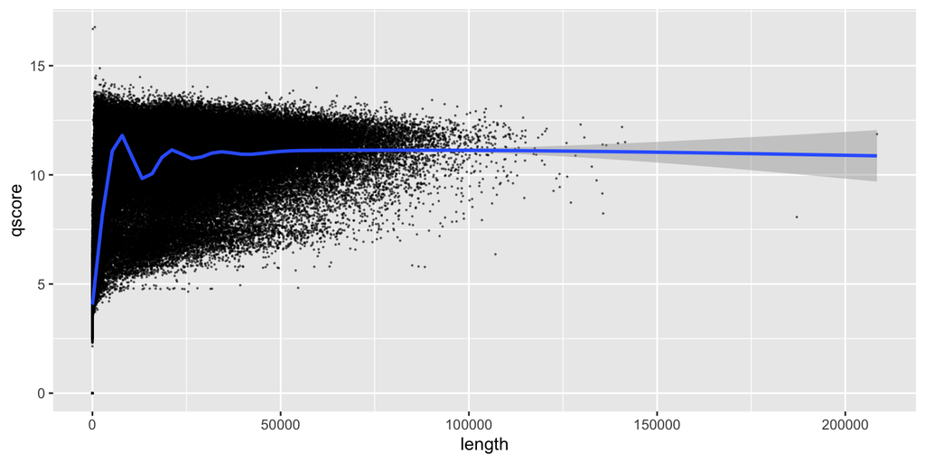

```r
ggplot(flowcell, aes(x = length, y = qscore)) +
  geom_point(size = 0.1, alpha = 0.5) +
  geom_smooth()
```

not much relationship seen here, could try length on log scale to zoom in on data

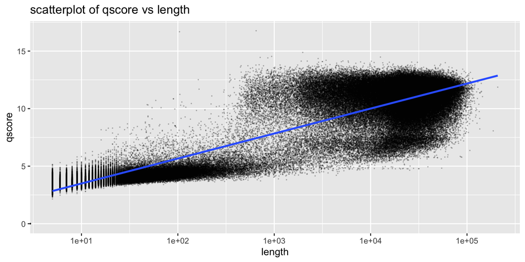

```r
ggplot(flowcell, aes(x = length, y = qscore)) +
  geom_point(size = 0.1, alpha = 0.2) +
  geom_smooth(method = "lm") +
  scale_x_log10() +
  ggtitle("scatterplot of qscore vs length")
```

on a log scale we can see a clear separation as expected because the qscore was bimodal this is also what we expected as longer codes should have a higher quality score

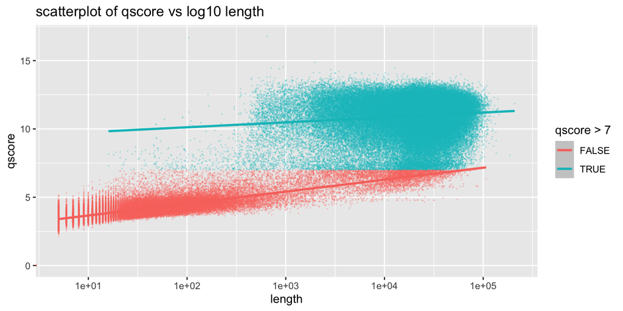

```r
ggplot(flowcell, aes(x = length, y = qscore, color = qscore > 7)) +
  geom_point(size = 0.1, alpha = 0.2) +
    geom_smooth(method = "lm") +
  scale_x_log10() +
  ggtitle("scatterplot of qscore vs log10 length")
```

As predicted longer reads ones have a higher quality score

# **Task 3**: Comparing flowcells

Make a visualisation to show how the output per channel (the total amount of data produced by each channel over the course of the run) varies between flowcell A and flowcell B.

we can see that they are different

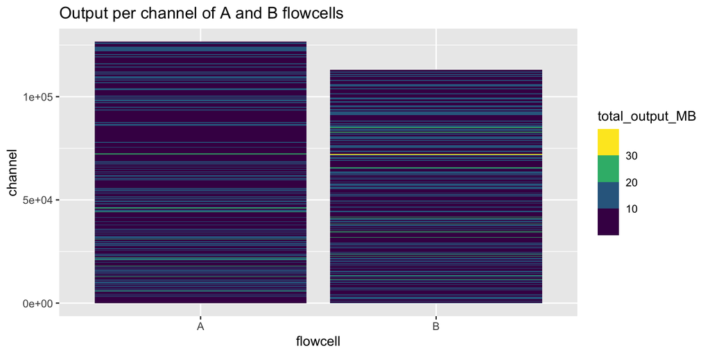

```r
ggplot(flowcell_summary, aes(x = flowcell, y =  channel, fill = total_output_MB)) +
  geom_col() +
  scale_fill_viridis_b() +
  ggtitle("Output per channel of A and B flowcells")
```

we can see flowcell A and B are different, but this probably isnt the best way to show the data

# **Task 4**: Are the flowcells faulty?

make different charts for flowcell A and B

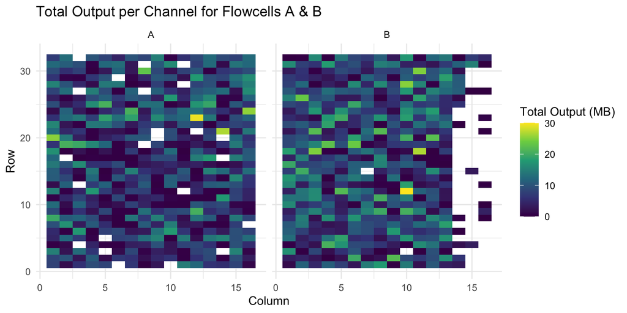

```r
ggplot(flowcell_summary, aes(x = col, y = row, fill = total_output_MB)) +
  geom_raster() +
  scale_fill_viridis_c() +
  facet_wrap(~ flowcell) +  # Creates separate plots for A & B
  labs(title = "Total Output per Channel for Flowcells A & B",
       x = "Column", y = "Row", fill = "Total Output (MB)") +
  theme_minimal()
```

certain channels seem fault, and there are more vaulty channels in flowcell B